# Além das notas: uma análise exploratória dos microdados do ENEM

Geovanna Silva Lacerda

Livia Neves Rodrigues Vitor Estevam

Miranda Hagata de Medeiros Pires

Taina Alves Marques

2026

# 1 Introdução

O Exame Nacional do Ensino Médio (ENEM) reúne informações importantes sobre o perfil dos participantes e a realidade educacional brasileira. Neste projeto, desenvolvido na disciplina de Métodos Computacionais para Ciências de Dados, serão explorados os microdados do ENEM referentes ao estado de Alagoas, contemplando características demográficas, socioeconômicas e escolares dos participantes, além de informações sobre as provas e seus respectivos desempenhos.

A partir desses dados, pretende-se investigar possíveis relações entre o contexto social e educacional dos participantes e seus resultados no exame, buscando identificar padrões, diferenças entre grupos e aspectos relacionados às desigualdades educacionais.

## 1.1 Objetivo geral

Analisar os microdados do ENEM no estado de Alagoas, investigando possíveis associações entre características demográficas, socioeconômicas e educacionais dos participantes e seus desempenhos no exame. Busca-se identificar padrões e diferenças entre grupos, utilizando técnicas de exploração, visualização e análise estatística de dados, com o auxílio da linguagem R.

## 1.2 Objetivos específicos

- Explorar o perfil dos participantes do exame.
- Investigar diferenças de desempenho entre grupos.
- Analisar relações entre condições socioeconômicas e notas.
- Investigar possíveis desigualdades relacionadas às características das escolas.
- Explorar diferenças de desempenho nas competências da redação.

# 2 Base de dados e preparação

## 2.1 Descrição da base

A base de dados utilizada neste trabalho é referente aos participantes do ENEM 2024 no estado de Alagoas. Para a realização da análise, foram utilizados dois arquivos: um com informações sobre os participantes e outro com informações sobre as escolas.

O primeiro arquivo contém dados sobre o perfil dos participantes, incluindo características demográficas, condições socioeconômicas e informações sobre sua trajetória escolar. Já o segundo contém informações sobre as escolas, como dependência administrativa, localização e situação de funcionamento.

## 2.2 Seleção das variáveis

As variáveis foram selecionadas de acordo com os objetivos da análise, considerando informações que permitissem conhecer melhor o perfil dos participantes e suas condições socioeconômicas e educacionais.

Foram utilizadas variáveis como faixa etária, sexo, cor/raça, estado civil e nacionalidade. Também foram consideradas informações sobre a escolaridade dos participantes e de seus responsáveis, o tipo de escola frequentada no Ensino Médio e a situação de conclusão dessa etapa.

Além disso, foram selecionadas variáveis relacionadas à renda familiar, à ocupação dos responsáveis, à quantidade de moradores no domicílio e ao acesso a bens e serviços, como internet, computador, celular, carro e motocicleta. Essas informações foram utilizadas para analisar possíveis relações entre as condições socioeconômicas e as características educacionais dos participantes.

## 2.3 Tratamento e limpeza dos dados

Inicialmente, foram importados os dois arquivos e as colunas utilizadas na análise tiveram seus nomes renomeados para facilitar sua identificação. Em seguida, as variáveis que estavam representadas por códigos numéricos ou alfabéticos foram transformadas em categorias descritivas, facilitando a interpretação dos dados e a construção dos gráficos.

Também foram agrupadas algumas categorias para facilitar as comparações durante a análise, como as faixas de renda familiar, a escolaridade dos responsáveis e a quantidade de moradores no domicílio.

Por fim, foi realizado o ajuste da codificação dos nomes dos municípios, corrigindo problemas relacionados à acentuação dos caracteres.

## 2.4 Considerações sobre os dados ausentes

Após o tratamento inicial, foi realizada uma verificação dos valores ausentes em cada coluna das duas bases. Essa verificação permitiu identificar a presença de informações faltantes, principalmente na variável referente à condição de treineiro dos participantes.

Também foram feitas verificações nas variáveis de faixa etária e dependência administrativa, desconsiderando os registros sem informação nessas categorias nas respectivas contagens e análises.

## 2.5 Bibliotecas utilizadas

Para o desenvolvimento do projeto, foram utilizadas bibliotecas do R com funções voltadas à importação, manipulação e visualização dos dados, além da construção do painel interativo.

- **readr:** utilizada na importação dos arquivos de dados em formato CSV.
- **tidyverse:** utilizada na manipulação e organização dos dados, incluindo seleção, filtragem, transformação e agrupamento de variáveis.
- **scales:** utilizada na formatação de valores e escalas dos gráficos, como a apresentação de percentuais.
- **shiny:** utilizada na construção do painel interativo, o que inclui a organização das páginas, os filtros por município e a navegação entre as seções.
- **sf:** utilizada no tratamento de dados espaciais para a representação geográfica dos municípios.
- **leaflet:** utilizada na construção de mapas interativos.
- **plotly:** utilizada na criação de gráficos interativos, permitindo a visualização de informações adicionais ao passar o cursor sobre os gráficos.

# 3 Exploração inicial das variáveis

## 3.1 Perfil dos participantes

#### 3.1.0.1 Faixa etária

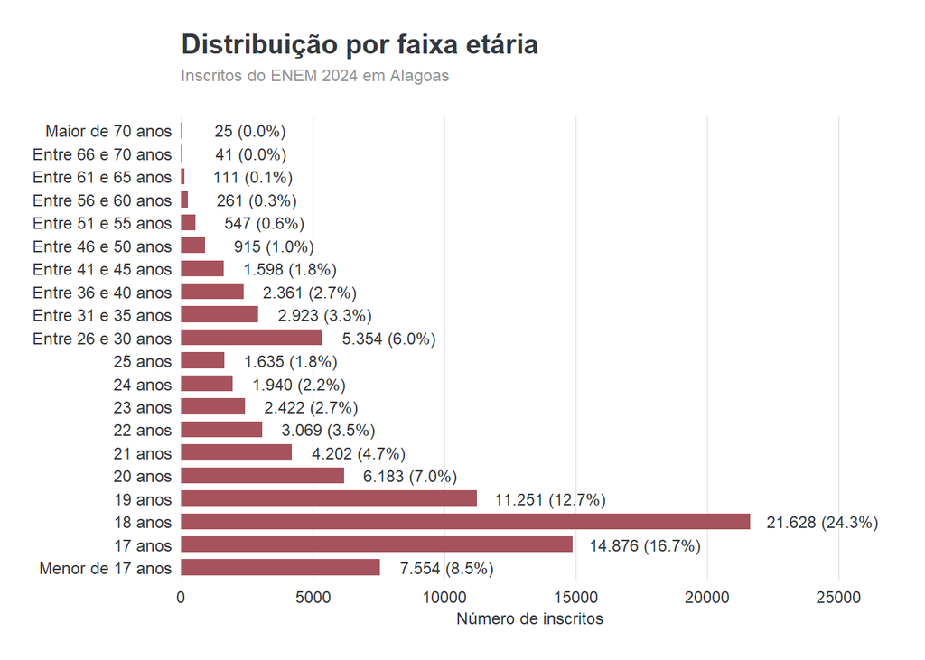

#### 3.1.0.2 Gênero

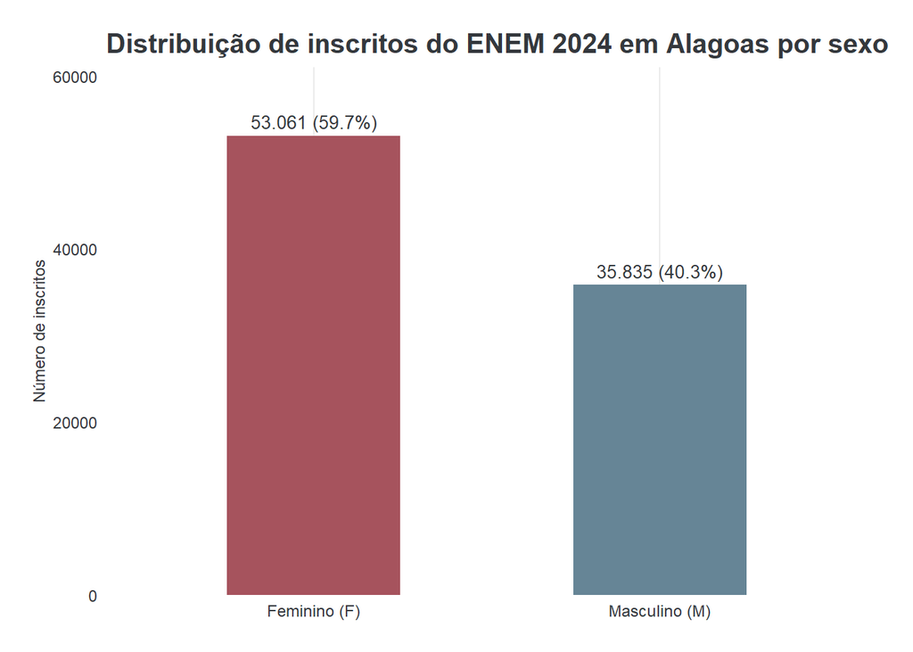

Cerca de 60% dos candidatos do ENEM em Alagoas em 2024 eram mulheres. Não é possível discernir acerca do desempenho deles. Apenas da distribuição.

#### 3.1.0.3 Cor/raça

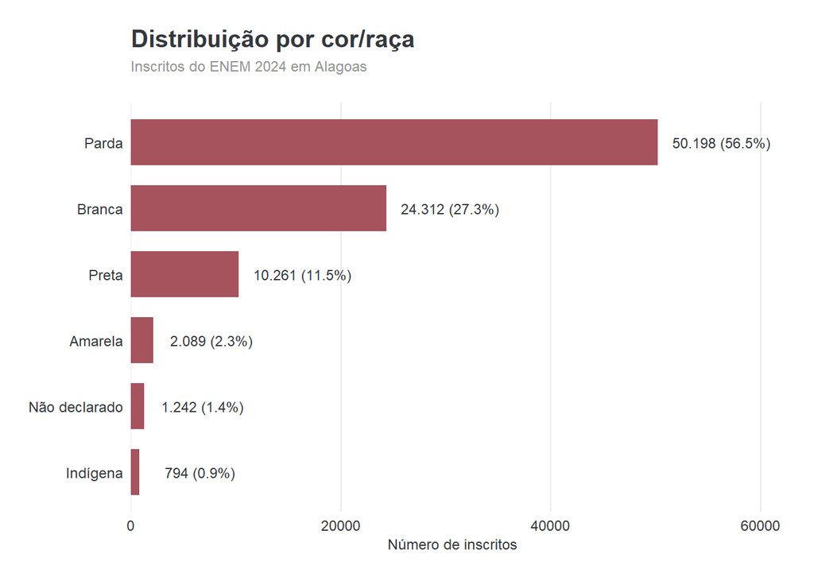

A maioria dos candidatos da prova de 2024 eram pardos (56%), 27% eram brancos e 11% se declararam pretos.

#### 3.1.0.4 Treineiro

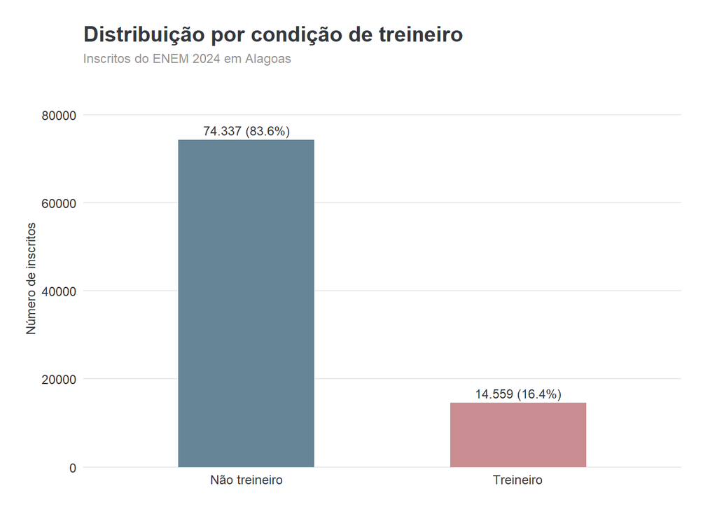

Configura-se como treineiro (16%) dos participantes. Essa mesma amostra será detectada na variável de conclusão do Ensino Médio até 2024.

#### 3.1.0.5 Estado civil

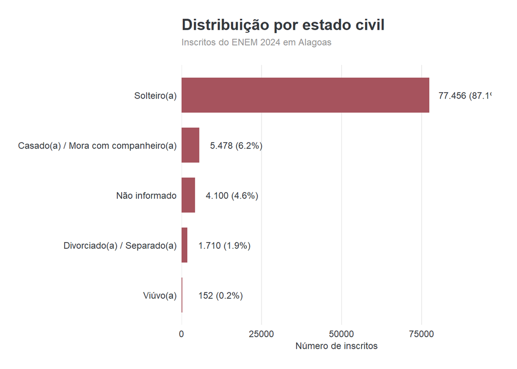

| estado_civil | n | pct |
| --- | --- | --- |
| Solteiro(a) | 77456 | 87.13 |
| Casado(a) / Mora com companheiro(a) | 5478 | 6.16 |
| Não informado | 4100 | 4.61 |
| Divorciado(a) / Separado(a) | 1710 | 1.92 |
| Viúvo(a) | 152 | 0.17 |

87% dos candidatos eram solteiros, o que condiz com a expectativa acerca da faixa etária que participava do exame

#### 3.1.0.6 Nacionalidade

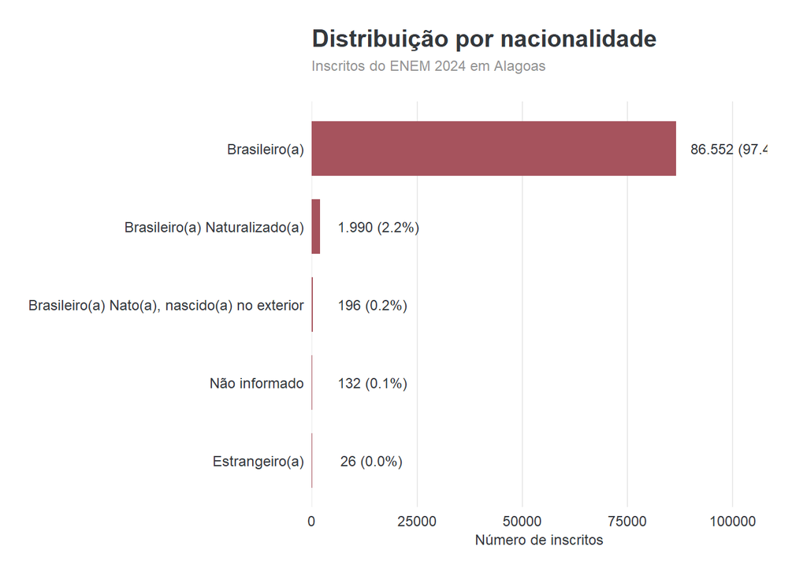

| nacionalidade | n | pct |
| --- | --- | --- |
| Brasileiro(a) | 86552 | 97.363 |
| Brasileiro(a) Naturalizado(a) | 1990 | 2.239 |
| Brasileiro(a) Nato(a), nascido(a) no exterior | 196 | 0.220 |
| Não informado | 132 | 0.148 |
| Estrangeiro(a) | 26 | 0.029 |

Quase 100% dos participantes do ENEM são brasileiros, 97% são natos e 2% são naturalizados

#### 3.1.0.7 Situação de conclusão do Ensino Médio

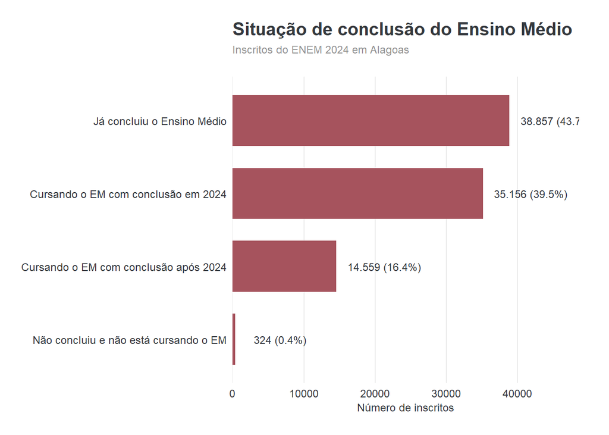

#### 3.1.0.8 Ano de Conclusão do Ensino Médio

Cerca de 85% dos candidatos ja possuem o ensino médio concluído ou concluem em 2024, ou seja, cerca de 15% não possuem o ensino médio concluído até o fim do exame.

## 3.2 Perfil socioecônomico

#### 3.2.0.1 Renda mensal

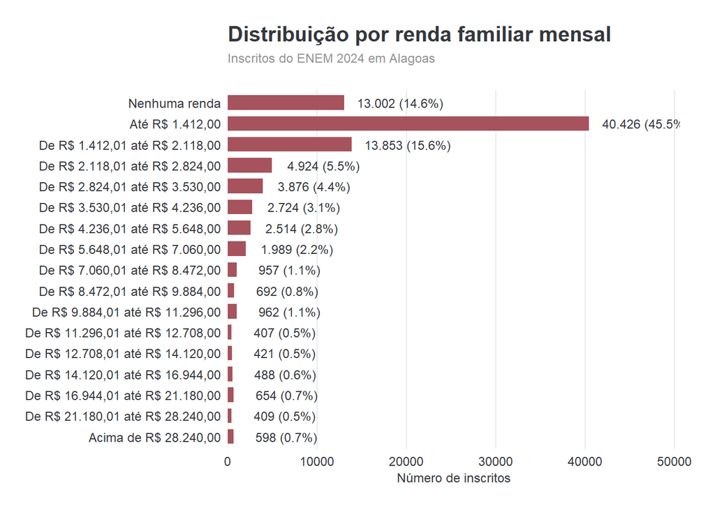

| renda_familiar_mensal | renda_rotulo | n | pct | pct_acumulado |
| --- | --- | --- | --- | --- |
| A | Nenhuma renda | 13002 | 14.63 | 14.63 |
| B | Até R$ 1.412,00 | 40426 | 45.48 | 60.11 |
| C | De R$ 1.412,01 até R$ 2.118,00 | 13853 | 15.58 | 75.69 |
| D | De R$ 2.118,01 até R$ 2.824,00 | 4924 | 5.54 | 81.23 |
| E | De R$ 2.824,01 até R$ 3.530,00 | 3876 | 4.36 | 85.59 |
| F | De R$ 3.530,01 até R$ 4.236,00 | 2724 | 3.06 | 88.65 |
| G | De R$ 4.236,01 até R$ 5.648,00 | 2514 | 2.83 | 91.48 |
| H | De R$ 5.648,01 até R$ 7.060,00 | 1989 | 2.24 | 93.72 |
| I | De R$ 7.060,01 até R$ 8.472,00 | 957 | 1.08 | 94.80 |
| J | De R$ 8.472,01 até R$ 9.884,00 | 692 | 0.78 | 95.58 |
| K | De R$ 9.884,01 até R$ 11.296,00 | 962 | 1.08 | 96.66 |
| L | De R$ 11.296,01 até R$ 12.708,00 | 407 | 0.46 | 97.12 |
| M | De R$ 12.708,01 até R$ 14.120,00 | 421 | 0.47 | 97.59 |
| N | De R$ 14.120,01 até R$ 16.944,00 | 488 | 0.55 | 98.14 |
| O | De R$ 16.944,01 até R$ 21.180,00 | 654 | 0.74 | 98.88 |
| P | De R$ 21.180,01 até R$ 28.240,00 | 409 | 0.46 | 99.34 |
| Q | Acima de R$ 28.240,00 | 598 | 0.67 | 100.01 |

#### 3.2.0.2 Tipo de escola do Ensino Médio

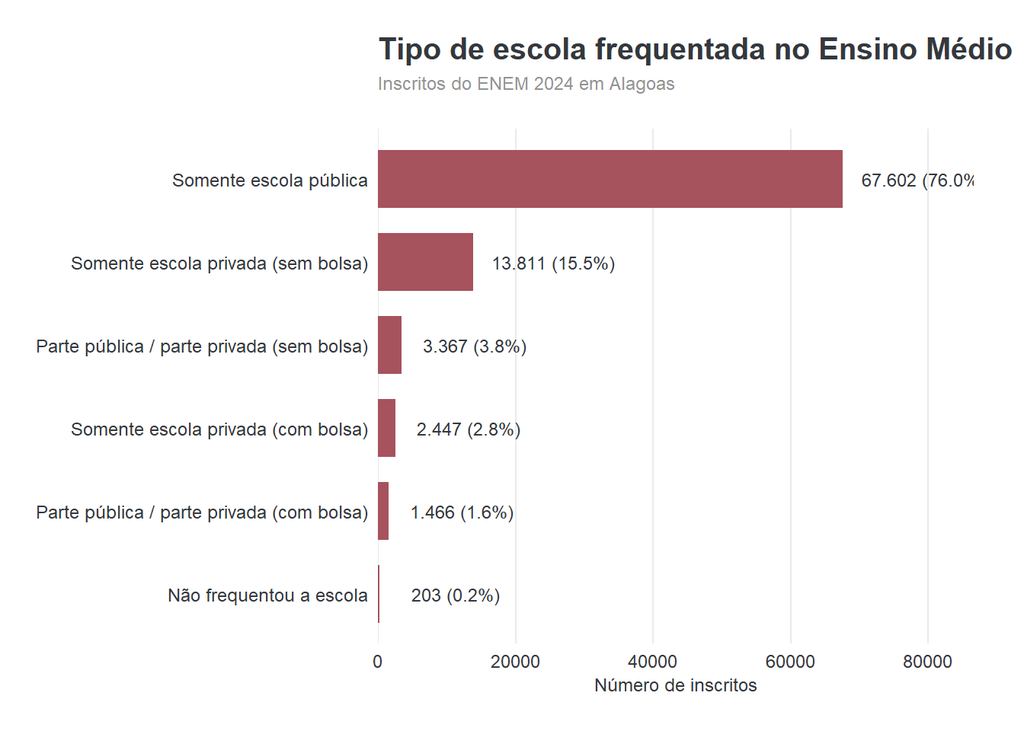

| tipo_escola_rotulo | n | pct |
| --- | --- | --- |
| Somente escola pública | 67602 | 76.05 |
| Somente escola privada (sem bolsa) | 13811 | 15.54 |
| Parte pública / parte privada (sem bolsa) | 3367 | 3.79 |
| Somente escola privada (com bolsa) | 2447 | 2.75 |
| Parte pública / parte privada (com bolsa) | 1466 | 1.65 |
| Não frequentou a escola | 203 | 0.23 |

#### 3.2.0.3 Análise familiar

**Escolaridade dos responsáveis**

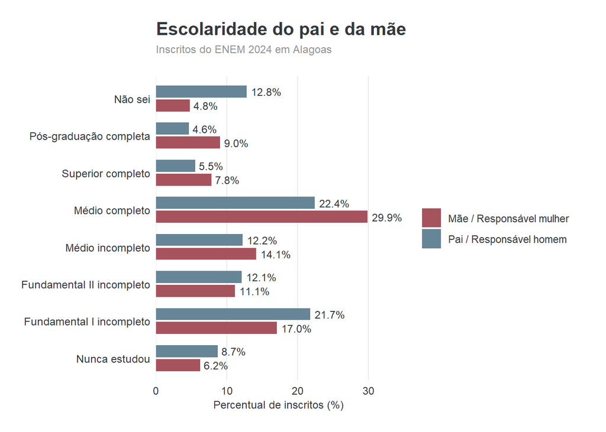

É possível perceber que a quantidade de “não sei” para os homens é mais de duas vezes maior do que para as mulheres responsáveis, além de que as mulheres estão mais presentes em níveis de ensino superior/pós graduação, ainda que a presença delas nas ocupações de cargos de nível superior seja equivalente à dos homens Em geral, é possível observar que as mulheres são, em média, no estado de AL, mais escolarizadas que seus pares homens, dado que a presença deles é superior apenas nos níveis de fundamental I e II incompletos e “nunca estudou”.

**Ocupação dos responsáveis**

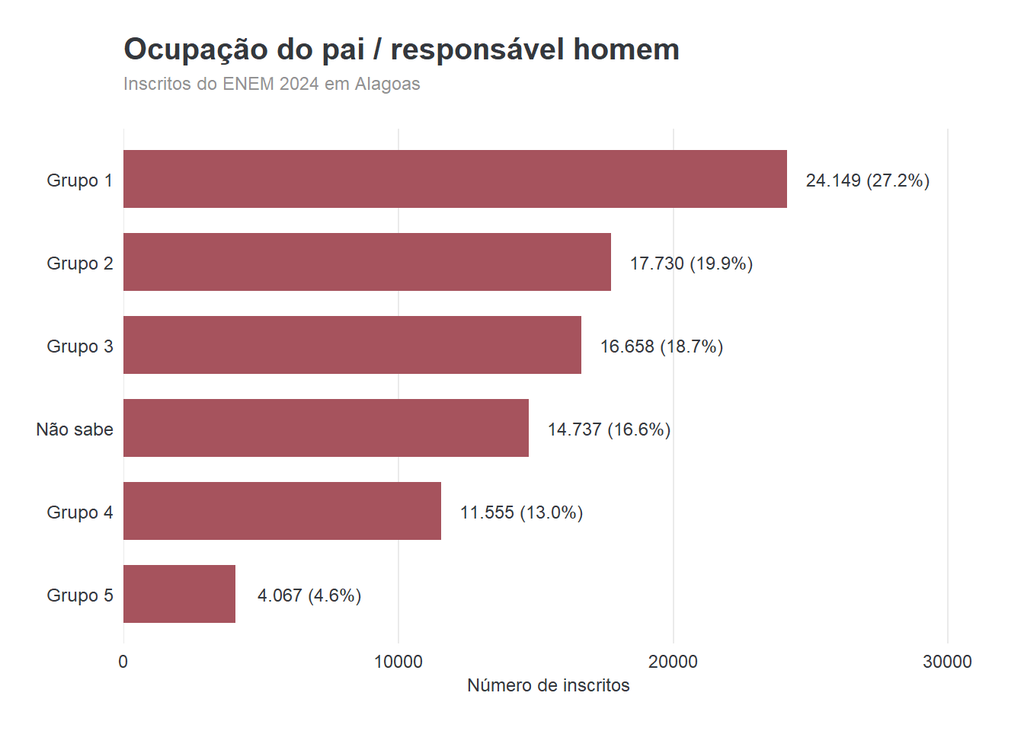

| ocupacao_pai | n | pct |
| --- | --- | --- |
| Grupo 1 | 24149 | 27.17 |
| Grupo 2 | 17730 | 19.94 |
| Grupo 3 | 16658 | 18.74 |
| Grupo 4 | 11555 | 13.00 |
| Grupo 5 | 4067 | 4.58 |
| Não sabe | 14737 | 16.58 |

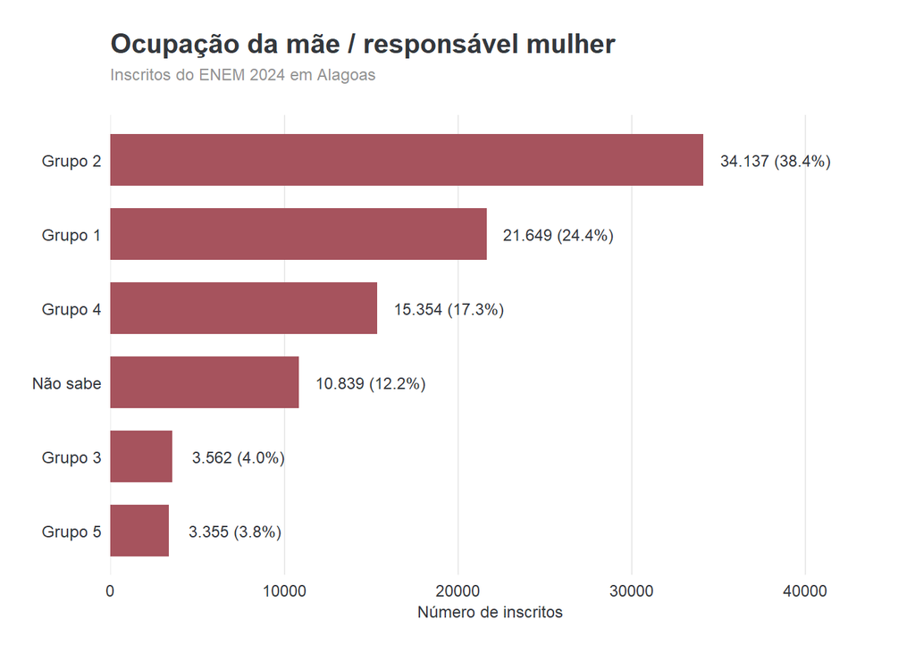

| ocupacao_mae | n | pct |
| --- | --- | --- |
| Grupo 1 | 21649 | 24.35 |
| Grupo 2 | 34137 | 38.40 |
| Grupo 3 | 3562 | 4.01 |
| Grupo 4 | 15354 | 17.27 |
| Grupo 5 | 3355 | 3.77 |
| Não sabe | 10839 | 12.19 |

Grupo 1: Agropecuária / Extrativismo;  
Grupo 2: Serviços gerais / Comércio / Doméstico;  
Grupo 3: Indústria / Construção / Transporte;  
Grupo 4: Técnico / Professor / Autônomo / Microemp;  
Grupo 5: Nível superior / Direção / Alta patente.

Quase 30% dos pais das famílias dos candidatos daquele ano trabalhavam em áreas ligadas ao setor extrativista, 20% no setor de serviços, 19% em trabalhos técnicos/indústria, 13% em setores técnicos especializados e 5% em ofícios de nível superior e altos cargos. Existe uma quantidade relevante de “não sabe”, equivalente a 17%. Associando essa variável à renda por meio do V de Cramér, foi possível obter um valor equivalente a 0,322 com um df* de 5, o que indica que existe uma forte associação entre a ocupação do pai/homem responsável com a renda da família.

As mulheres estão mais presentes em relação aos homens no setor de serviços (38%), seguido de atividades agropecuárias e extrativistas (24%), setor técnico especializado (17%), 4% está na indústria e 4% figura em altos cargos ou de nível superior. Observa-se que existe uma diferença relevante nos papéis de gênero no mercado de trabalho, com as mulheres menos presentes nas indústrias e em trabalhos ligados ao extrativismo/agropecuária, mas mais presentes em cargos técnicos e no setor de serviços do que os homens. Existe uma quantidade menor, mas ainda relevante de “não sabe”, que corresponde a 12% das respostas. Associando a ocupação da mãe com a renda familiar através do V de Cramér, obteve-se um valor muito semelhante ao dos homens, de 0,31, com mesmo df*, implicando que tanto para os homens, quanto para as mulheres responsáveis, existe uma associação forte entre suas ocupações e a renda familiar dos candidatos no Alagoas em 2024.

**Renda familiar e composição domiciliar**

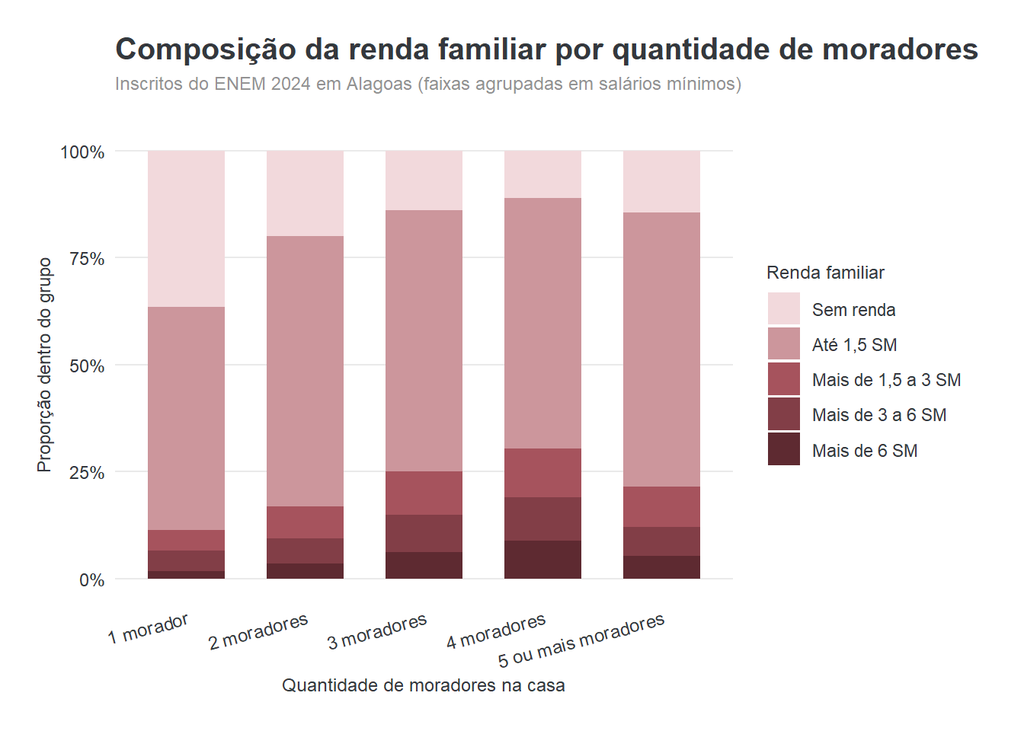

Existe uma tendência de que quanto mais pessoas moram na casa até 4 pessoas, as faixas de maiores rendas crescem. Isso pode sugerir que existem mais pessoas contribuindo para a renda familiar. Apesar disso, a correlação encontrada através do coeficiente de Spearman resultou em um valor considerado desprezível (0,057), mostrando que não há correlação relevante entre renda e quantidade de moradores nas famílias dos candidatos do ENEM 2024 em Alagoas.

**Associações com escolaridade da mãe**

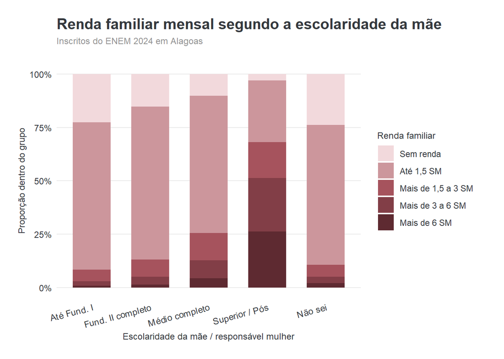

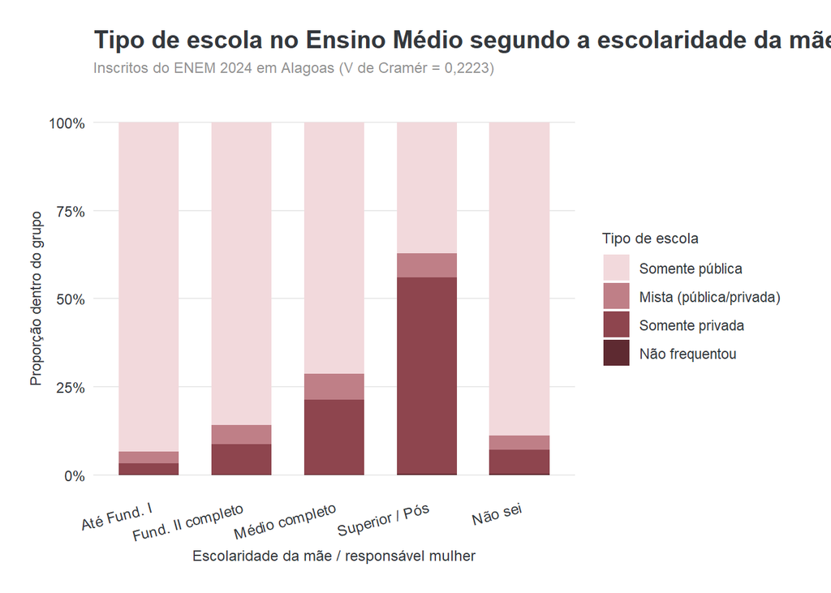

O V de Cramér de 0,222 e um df* de 5, mostra uma associação de força moderada a forte entre a escolaridade da mãe e o tipo de escola que o filho frequenta. Ou seja, filhos de mães mais escolarizadas tendem a ter maiores chances de estudarem em escolas particulares do que filhos de mães menos escolarizadas

Já na correlação entre escolaridade da mãe e renda familia, o teste de Spearman resultou em um coeficiente de 0,467, indicando uma associação de força também moderada a forte entre a escolaridade da mãe e a renda familiar.

#### 3.2.0.4 Acesso à tecnologia

**Internet por rede WI-FI**

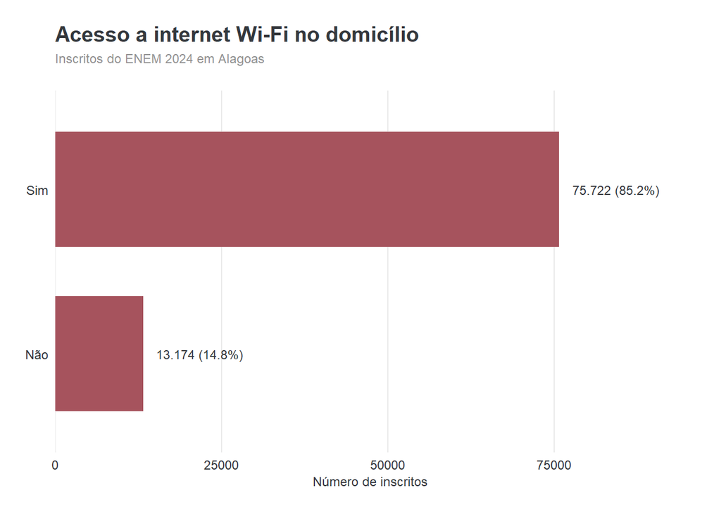

**Computador/Notebook**

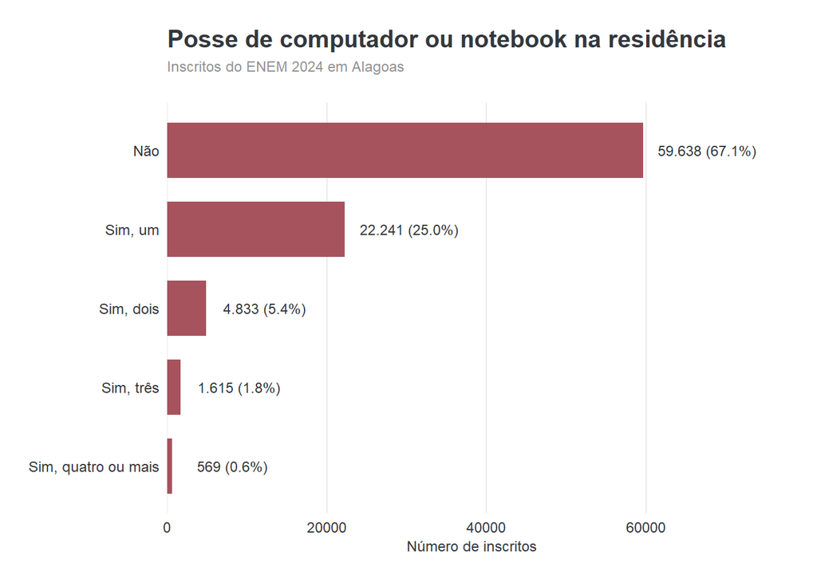

67% dos candidatos não possuíam nenhum computador ou notebook em casa, enquanto 25% possuíam apenas um, 5% possuíam 2, 2% possuíam 3 e apenas 0,64% possuíam 4 ou mais. Essa variável apresentou uma associação particularmente forte com a renda, tendo uma das associações mais fortes entre si. (V de Cramér = 0,383; df* = 4). Isso significa que ter ou não um computador em casa e quantos indica de forma relativamente consistente o nível aquisitivo daquela família.

**Telefone Celular**

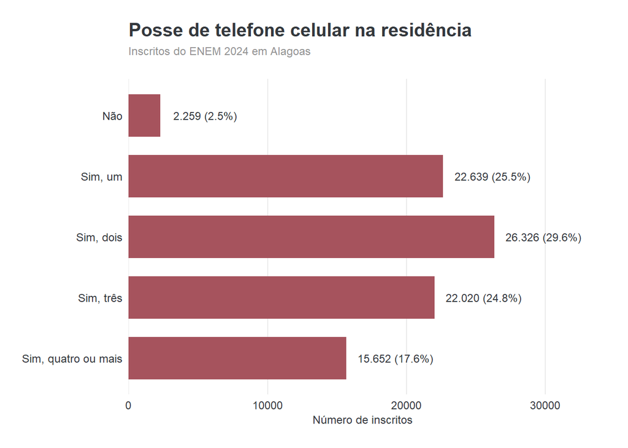

Apenas 3% dos lares dos candidatos ao ENEM de Alagoas no ano de 2024 não possuíam nenhum telefone celular em casa. 25% possuíam apenas um, 30% possuíam dois, 25% possuíam 3, enquanto 18% possuíam quatro ou mais. Ainda que o V de Cramér = 0,263; df* = 4 indique uma associação forte entre a quantidade de celulares e a renda familiar, é possível afirmar que é um indicador de renda menos robusto do que a posse de computadores na residência, o que mostra que os celulares se apresentam como meios mais democráticos de acesso à tecnologia do que os computadores.

#### 3.2.0.5 Acesso à mobilidade

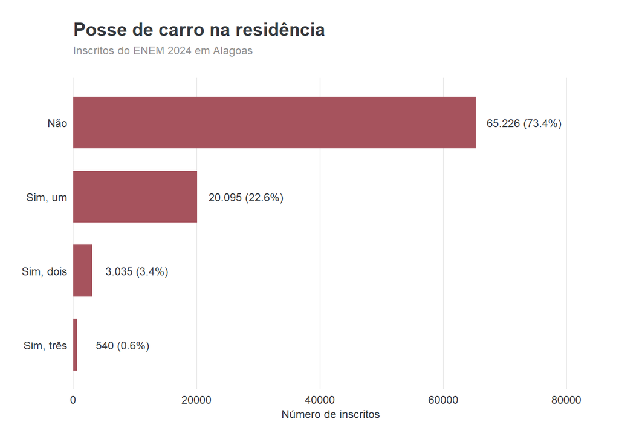

73% das famílias dos candidatos não possuíam carro em 2024, 23% possuíam apenas um, enquanto 4% possuía dois ou mais o que mostra que o carro é um bem relativamente inacessível para a população. O V de Cramér = 0,4279; df* = 4 corrobora essa interpretação. Entre todas as variáveis categóricas analisadas via V de Crámer,, ter ou não carros é o fator que mais se associa à renda familiar, sendo a melhor para distinguir o estrato econômico de um candidato.

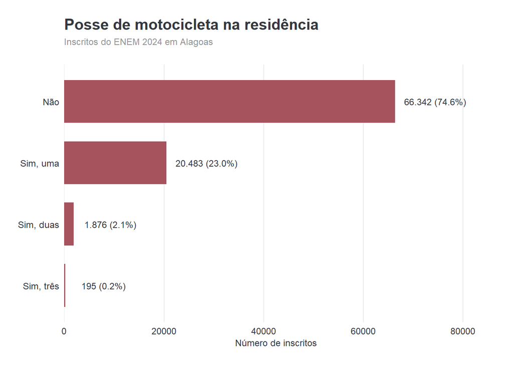

75% das famílias não possuíam motocicletas, 23% possuíam uma e 2% possuíam duas ou mais. O V de Cramér = 0,0887; df* = 3 mostra que a associação entre ter motocicleta e a renda é fraca, o que significa que essa variável não discerne de forma consistente os participantes em relação à renda familiar, além de sugerir que motocicletas são meios de transporte mais acessíveis e democratizados

## 3.3 Características das escolas

#### 3.3.0.1 Dependência administrativa

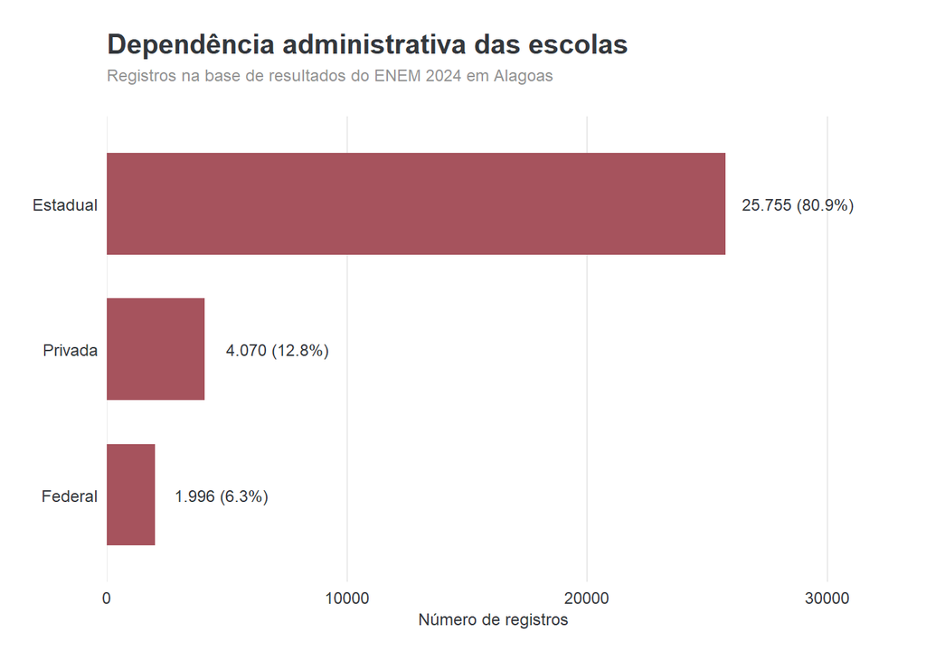

Em relação à dependência administrativa, observa-se uma predominância das escolas estaduais, que representam 80,9% dos registros, com 25.755 ocorrências. Em seguida, aparecem as escolas privadas, com 4.070 registros (12,8%), e as federais, com 1.996 (6,3%). Dessa forma, a maior parte dos registros da base corresponde à rede estadual de ensino.

#### 3.3.0.2 Localização

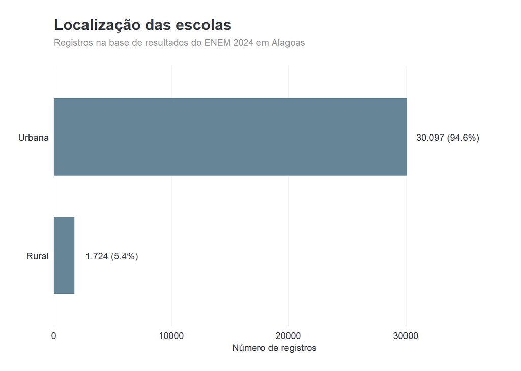

Quanto à localização, a maioria das escolas está situada na zona urbana, que representa 94,6% dos registros, com 30.097 ocorrências. Já as escolas rurais correspondem a 5,4%, com 1.724 registros. Assim, observa-se uma concentração expressiva de escolas localizadas em áreas urbanas.

#### 3.3.0.3 Situação de funcionamento

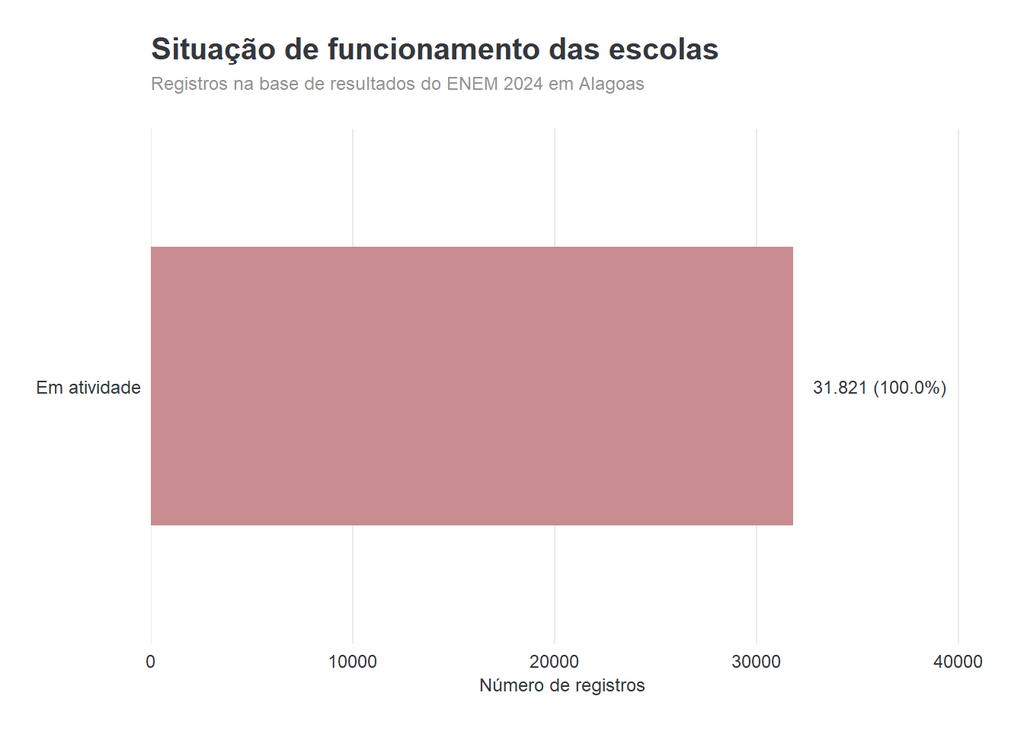

Antes do tratamento dos valores ausentes, 64,2% dos registros não apresentavam informações sobre a situação de funcionamento das escolas, enquanto 35,8% possuíam essa informação. Após a retirada dos valores faltantes para essa análise, foram considerados 31.821 registros, todos correspondentes a escolas em atividade.

Dessa forma, apesar de todos os registros válidos indicarem escolas em atividade, a quantidade de dados não informados na base original limita essa análise. Portanto, não é possível afirmar que todas as escolas participantes estavam em atividade, mas apenas que essa foi a situação identificada em todos os registros com informação disponível.

# 4 Análise dos resultados

## 4.1 Presença

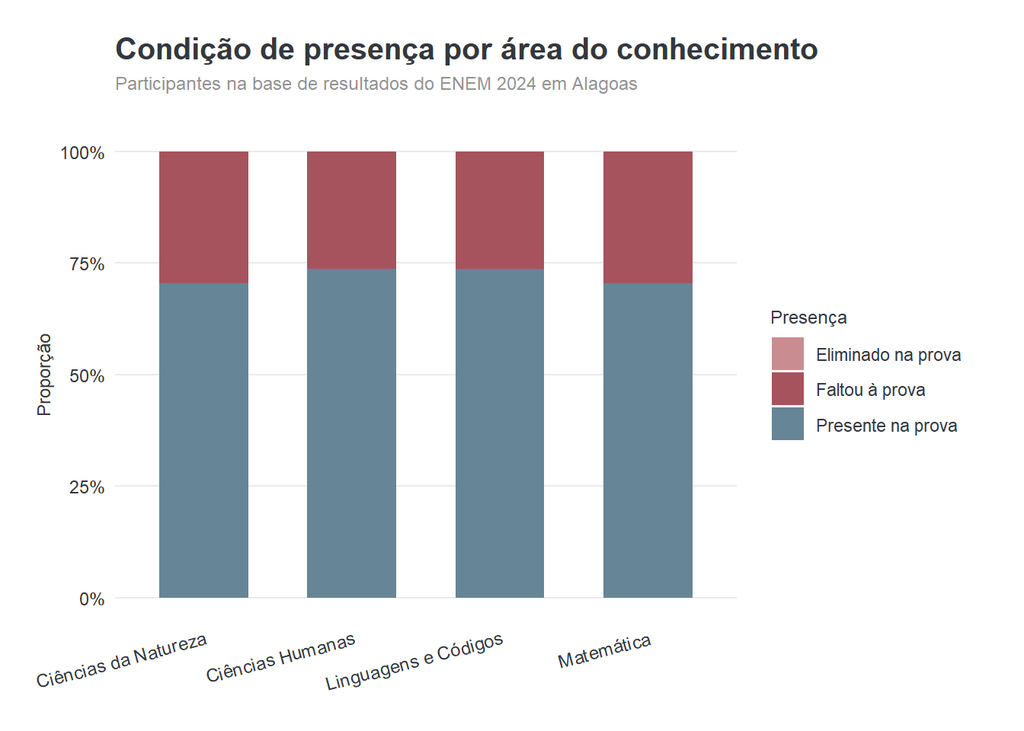

A condição de presença apresenta resultados semelhantes entre as quatro áreas do conhecimento. Em todas elas, a maior parte dos participantes esteve presente na prova, com percentuais entre aproximadamente 70% e 74%. Já os participantes que faltaram representam cerca de 26% a 30% dos registros. Assim, observa-se que a maioria compareceu às provas, embora a quantidade de ausências também seja significativa.

## 4.2 Resultados

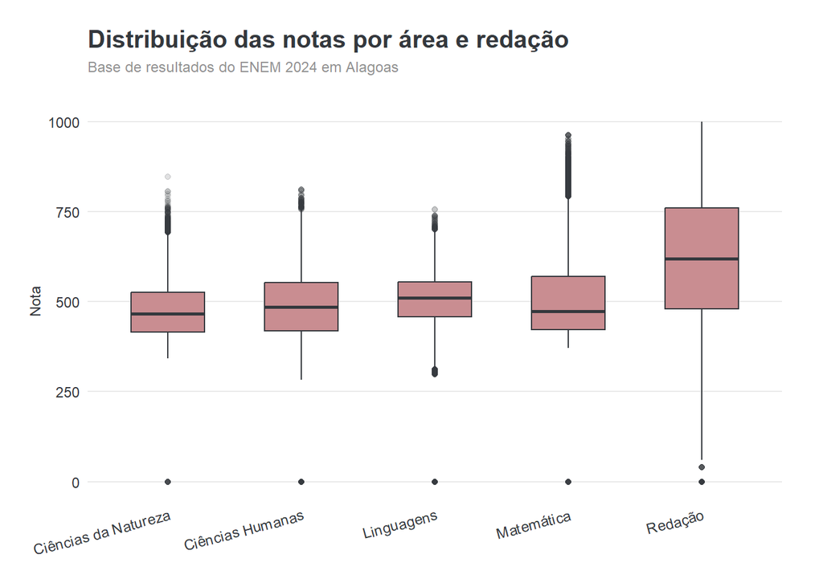

A distribuição das notas apresenta diferenças entre as áreas do conhecimento e a redação. Nas provas de Ciências da Natureza, Ciências Humanas, Linguagens e Matemática, as notas estão mais concentradas entre aproximadamente 400 e 575 pontos, com medianas entre 460 e 510 pontos. A redação, por outro lado, apresenta valores mais elevados, com mediana próxima de 620 pontos e maior concentração de notas entre 480 e 760 pontos.

Também é possível observar valores atípicos em todas as áreas, com notas próximas de zero e outras bastante elevadas. Dessa forma, a distribuição das notas não é uniforme, apresentando diferenças tanto entre as áreas quanto entre os participantes.

## 4.3 Desempenho

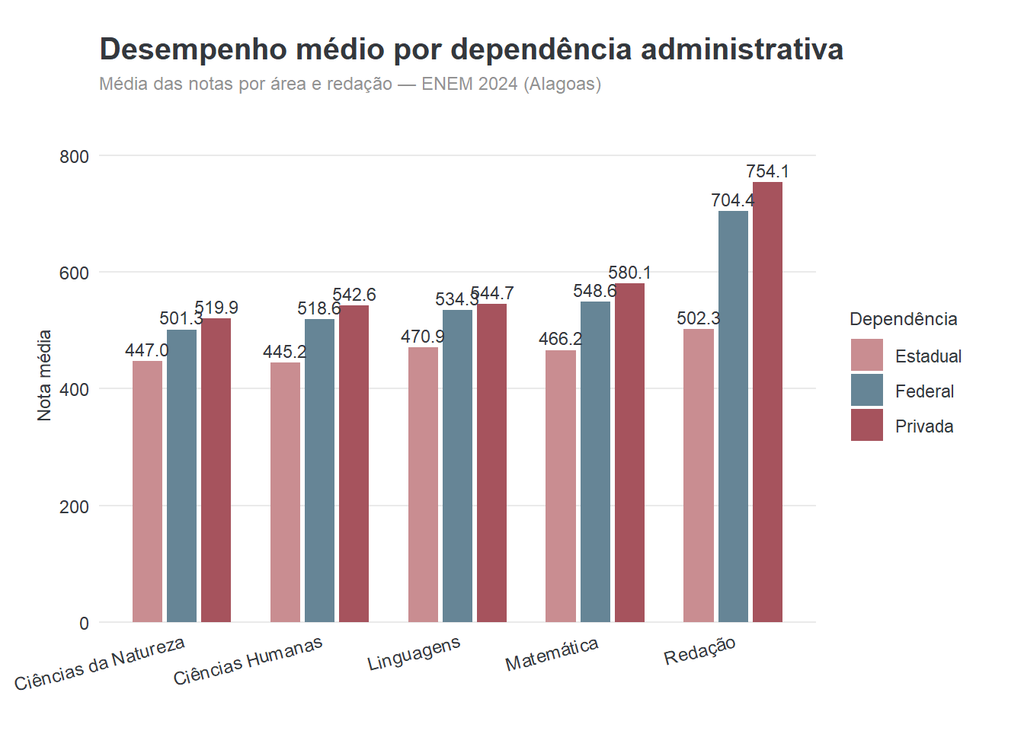

Ao comparar as médias por dependência administrativa, observa-se que as escolas estaduais apresentam os menores resultados em todas as áreas, enquanto as escolas privadas possuem as maiores médias. As escolas federais apresentam resultados intermediários.

A maior diferença aparece na redação, em que a média das escolas estaduais é de 502,3 pontos, enquanto a das federais é de 704,4 e a das privadas, de 754,1 pontos. Em Matemática, também há uma diferença expressiva, com médias de 466,2 nas escolas estaduais, 548,6 nas federais e 580,1 nas privadas.

Portanto, os resultados mostram diferenças nas médias de acordo com a dependência administrativa, com desempenho médio superior nas escolas privadas e federais em comparação às estaduais. Essa comparação, entretanto, não permite afirmar que a dependência administrativa seja a causa dessas diferenças.

# 5 Conclusão

A análise dos microdados do ENEM 2024 em Alagoas permitiu identificar diferenças no perfil dos participantes e associações entre suas condições socioeconômicas e educacionais. Entre os resultados encontrados, destaca-se a relação entre a renda familiar e características como a escolaridade e a ocupação dos responsáveis, além do acesso a bens e serviços. A posse de computador e de carro, por exemplo, apresentou associações mais fortes com a renda familiar.

Também foi possível observar que a escolaridade da mãe está associada tanto à renda familiar quanto ao tipo de escola frequentada pelo participante. Esses resultados mostram que as condições familiares estão relacionadas às oportunidades educacionais dos estudantes.

Em relação ao desempenho, foram identificadas diferenças nas médias de acordo com a dependência administrativa das escolas. As escolas privadas e federais apresentaram médias superiores às estaduais em todas as áreas analisadas, com diferenças mais expressivas na redação.

De modo geral, os resultados indicam que o desempenho dos participantes está inserido em um contexto que envolve diferentes condições sociais, econômicas e educacionais. Entretanto, é importante considerar que as associações identificadas não estabelecem relações de causa e efeito. Além disso, a presença de valores ausentes em algumas variáveis limita parte das análises realizadas.

Assim, o trabalho permitiu explorar diferentes aspectos da realidade dos participantes do ENEM em Alagoas e identificar padrões que ajudam a compreender as desigualdades presentes no contexto educacional do estado.

## 5.1 Referências

**R Core Team (2026).** *R: A Language and Environment for Statistical Computing*. R Foundation for Statistical Computing, Vienna, Austria. https://www.R-project.org/.

**INSTITUTO NACIONAL DE ESTUDOS E PESQUISAS EDUCACIONAIS ANÍSIO TEIXEIRA (INEP).** Microdados do Exame Nacional do Ensino Médio (ENEM) 2024. Brasília, DF: Inep, 2025. Disponível em: [Microdados do ENEM](https://www.gov.br/inep/pt-br/acesso-a-informacao/dados-abertos/microdados/enem?utm_source=chatgpt.com). Acesso em: 26 nov. 2026.